# RNA-Seq Pre-processing

Lauren Vanderlinden

11/9/2020

This document goes over how data was processed up to RSEM quantitation and then records how the RNA-sequencing data is processed starting from RSEM results to data used for statistical analyses.

### Pre-processing

**Trimming**

Data were first trimmed by using the general cutadapt (version 1.18) code:

```r
cutadapt -u 15 -U 15 -q 20 -m 20 -a AGATCGGAAGAGCACACGTCTGAACTCCAGTCA -A AGATCGGAAGAGCGTCGTGTAGGGAAAGAGTGT -o $f_trimmed -p $f2_trimmed $f $f2
```

The shell script files (.sh) to run the batches of this are located on csphbiostats and have the general format of:

```r
/home/vanderll/Norris/RNAseq_processing/programs/trimmReads/trimmReads.batch##.sh
```

**Merging Runs**

We had each sample run 2 times to get enough reads. Needed to merge the trimmed files. This is the program to merge the trimmed fastq files:

```r
/home/vanderll/Norris/RNAseq_processing/programs/trimmReads/cat_trimmedFiles.sh
```

**Aligning & Quanitating**

Data were aligned and quantitated using RSEM (v1.3.2). The general RSEM code is as follows:

```r
rsem-calculate-expression -p 8 --time --seed 2020 --bowtie2 --paired-end /home/biostats_share/Norris/data/RNAseq/trimmedReads_cat/SAMPLE_R1.fastq /home/biostats_share/Norris/data/RNAseq/trimmedReads_cat/SAMPLE_R2.fastq  /home/biostats_share/Norris/data/annotation/hg19/rsem_ref/hg19 SAMPLE
```

The programs to align & quantiate have the general format:

```r
/home/vanderll/Norris/RNAseq_processing/programs/quantitation/rsem_code_batch###.txt
```

**Merging into Matrix**

The code to merge into a single count matrix used moving forward is:

```r
/home/vanderll/Norris/RNAseq_processing/programs/getFinalMatrix/getRSEMcountMatrix.geneLevel.R
```

### Overview

These are the steps we will perform now that we have all the data together in 1 matrix:

**1.** Remove Low Abundant (poor QC) Samples

**2.** Filter Features Not Detected Above Background

**3.** Filter Samples with High 0 Counts

**4.** Normalize data using empirical RUV method

**5.** Transform data using rlog

We have a total of **308** RNA-sequencing samples **4** batches.

**Samples/Batch**

The following table shows the number of samples run per batch:

| Batch | NumberOfSamples |
| --- | --- |
| Batch 1 | 96 |
| Batch 2 | 96 |
| Batch 3 | 96 |
| Batch 4 | 20 |

**Technical Replicates**

Here is a table of the technical replicates:

|  | Number Technical Replicates |
| --- | --- |
| 110424 | 2 |
| 110507 | 2 |
| 110537 | 2 |
| 110538 | 2 |
| 110539 | 2 |
| 110562 | 2 |
| 110583 | 2 |
| 110627 | 2 |
| 110680 | 2 |
| 110688 | 2 |
| 110690 | 2 |
| 110713 | 2 |

**Number of Genes**

Quantitating using the hg19 Ensembl transcriptome build v87, we have **57,736** genes.

### Step 1. Remove Low Signal Samples

Visualizing the distributions of total count sum:

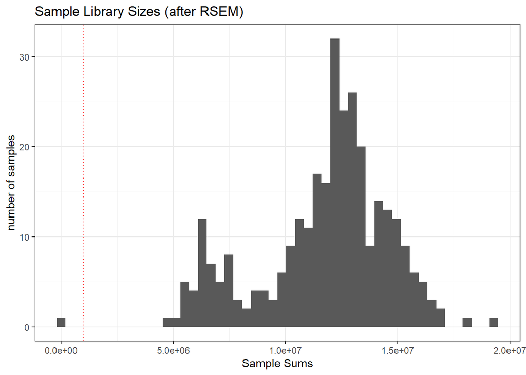

There is 1 really low total count sample. This is sample: 110627_4. It has a total of 135,349 expected counts.

This is a technical replicate, so at least it’s not a true sample. Going to remove this from the analysis and move onto the next step.

**Lauren TO DO:** All runs looked to have okay number of total reads. Where did this go wrong. Was it after trimming (poor reads) or quantitation (poor alignment) or both?

If we split this up based on batch:

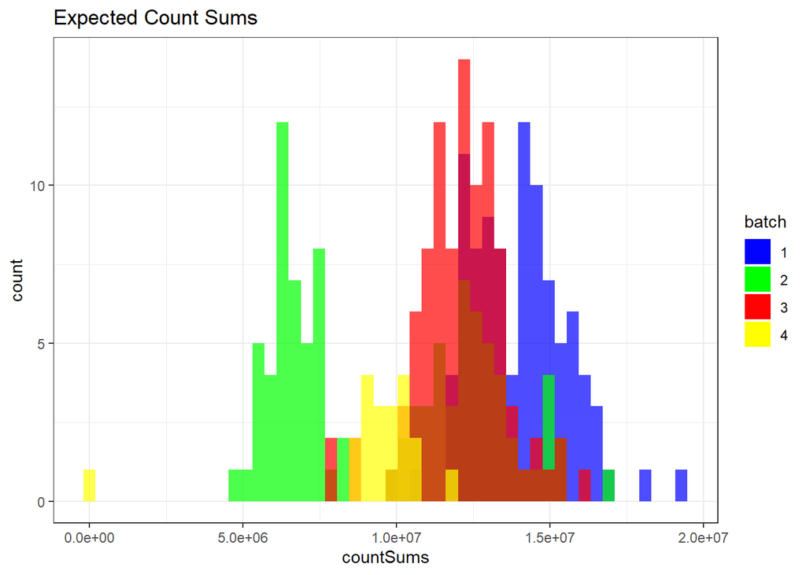

This seems to be a batch thing, like we saw before. We will keep moving forward and see how well the normalization and transformation take care of this.

### Step 2. Feature Detection Above Background

Features will be kept in if there are at least 20% of samples with at least 1 count. In the histogram below, all features right of the red dotted line are removed. We are keeping ~39% of the features. Here is a visualization of the number of samples with a 0 counts and we are keeping everything left of the dotted line:

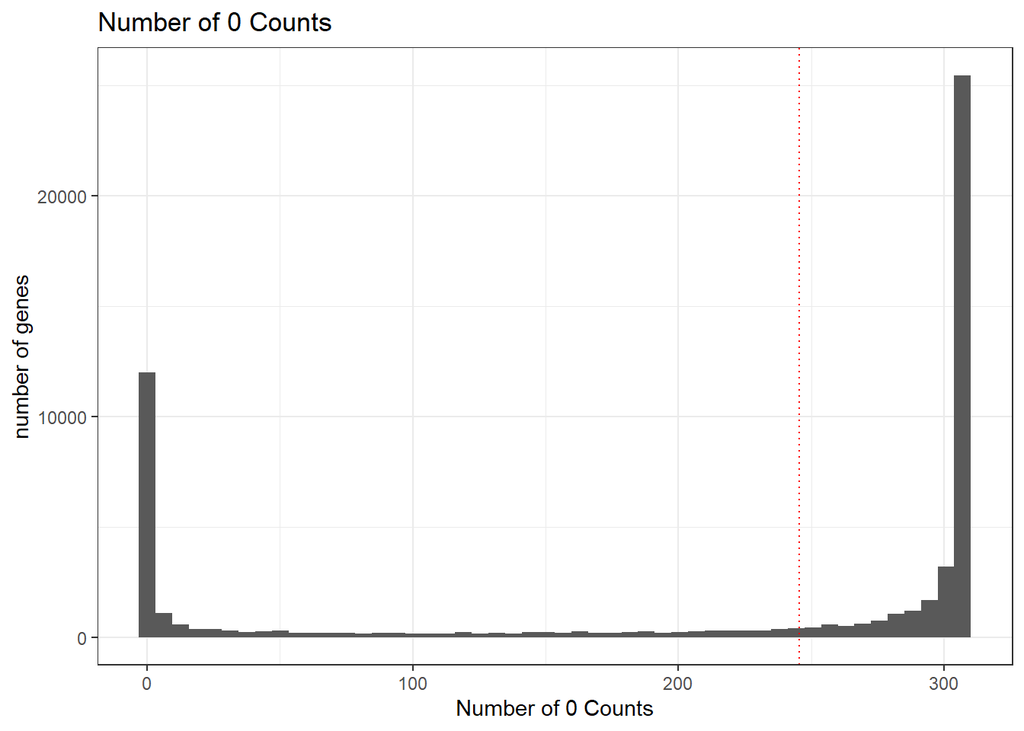

### Step 3. Sample QC for High 0 Counts

We want to remove samples where we have a high number of 0 counts. If a sample has 0 counts for > 1/2 of the features, it will be removed from the analysis.

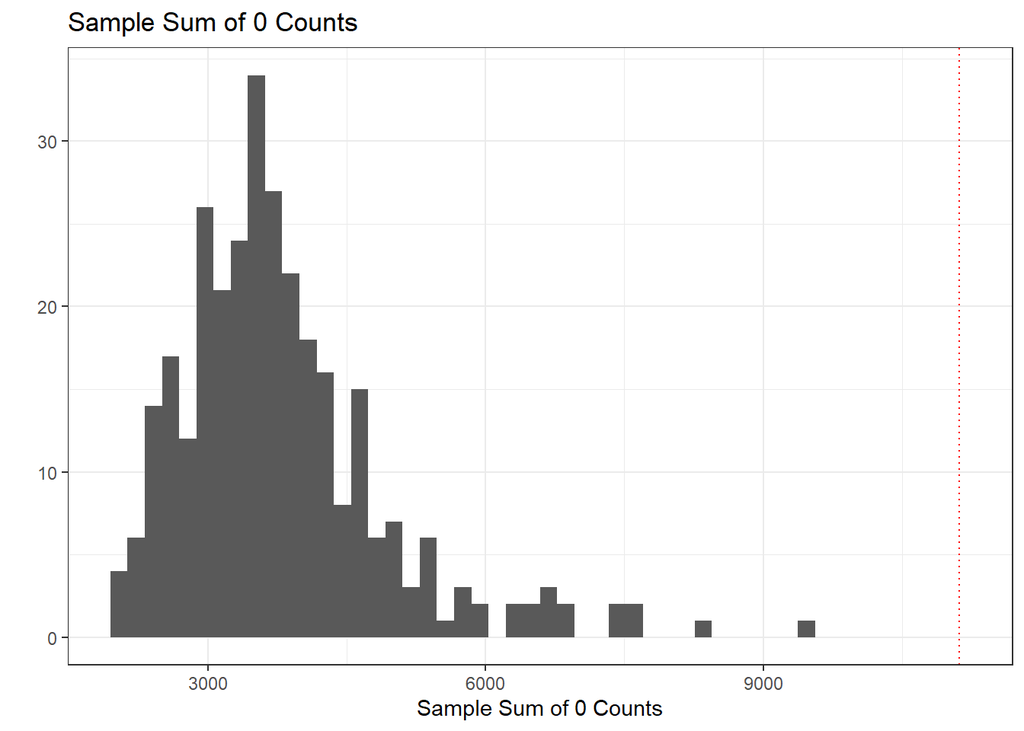

So none of the samples have 0 counts in over half the features. There is a tail there were a few samples do have a high 0 count, so may reconsider in the future, but for now keep all in.

### Summary of Pre-Processing Filtering Steps (Steps 1-3)

| Filter | Description | Total Number of Genes | Total Number of Samples |
| --- | --- | --- | --- |
| None | original data set | 57,736 | 308 |
| Remove Low Abundant Samples | remove samples <1 million reads) | 57,736 | 307 |
| Features Detected Above Background | At least 20% samples have 1 count | 22,236 | 307 |
| Remove Samples with High 0 Counts | More than 1/2 of genes are 0 counts | 22,236 | 307 |

### Visualization Pre-Normalization

Just want to look at the data in a few different ways prior to normalization to see how well the normalization worked. Going to look at a PC plot as well as a dendrogram. To do this, I’m going to perform log2(count+1) transformation. This is JUST for visualization purposes. This also is a method to see if there are any outliers (based on poor correlation among other samples) that should be removed prior to the analysis.

**Dendrogram**

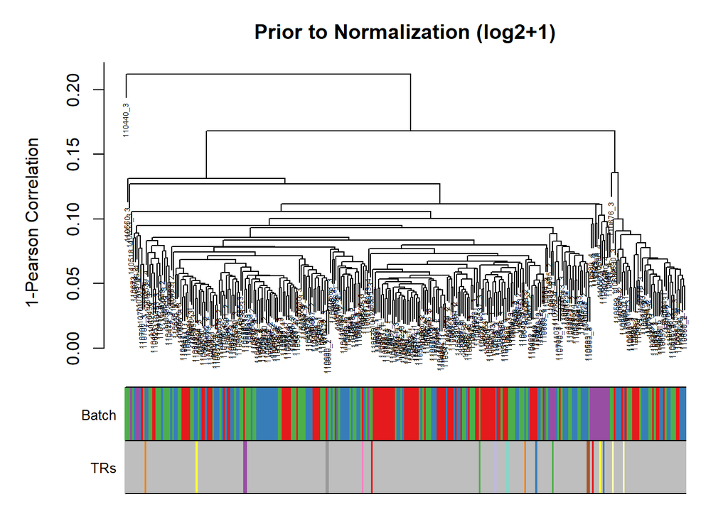

I’m going to remove that one outlier that is on the top left. This is sample 110440 and is the same outlier as prior to normalization. It’s a maintainer RNA visit 1.

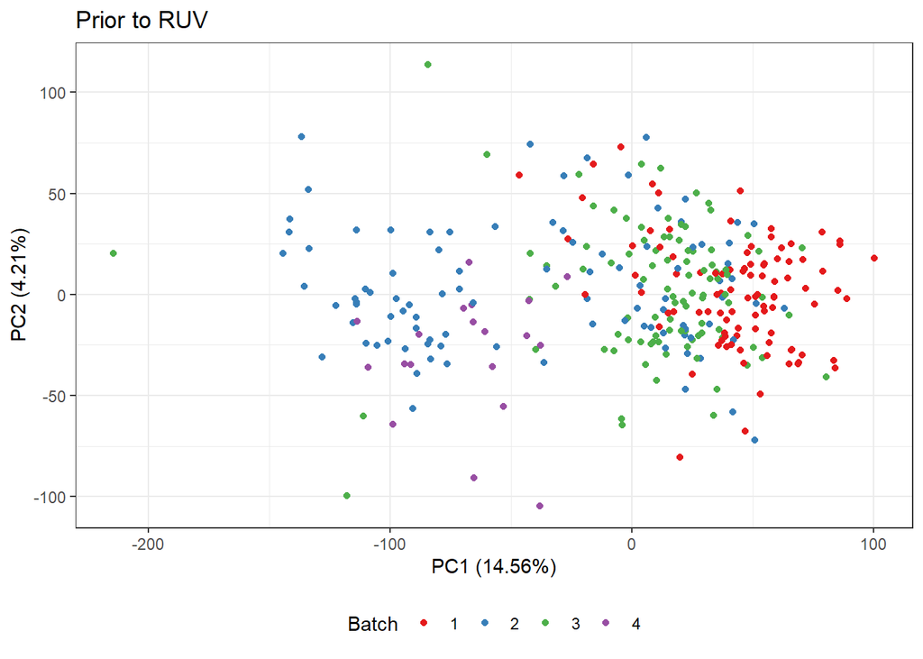

That outlier (clearly seen in the dendrogram) which will be removed prior to RUV, is the sample on the far left of the PC plot (PC1 value = -214.4 and PC2 value = 20.39).

The outier is sample 110440 and is the same outlier as prior to normalization. It’s a maintainer RNA visit 1.

### Step 4. Normalize Data Using RUV Empirical Method

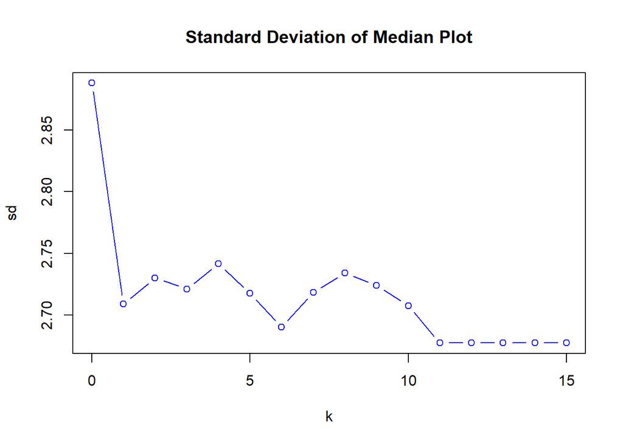

This is a diagnostic plot to look at where the elbow is and use that as the number of factors to adjust out. So here the best looking one is **k=1**.

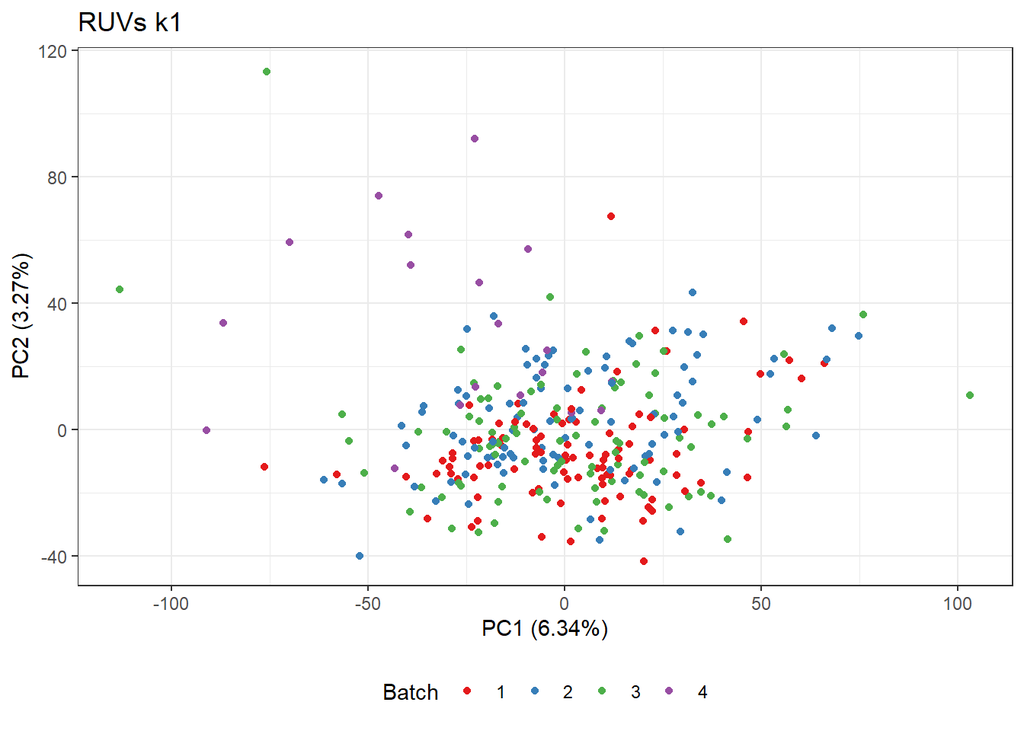

### Step 5. Regularized Log Transformation

Took about 16 hours to run. Not too bad.

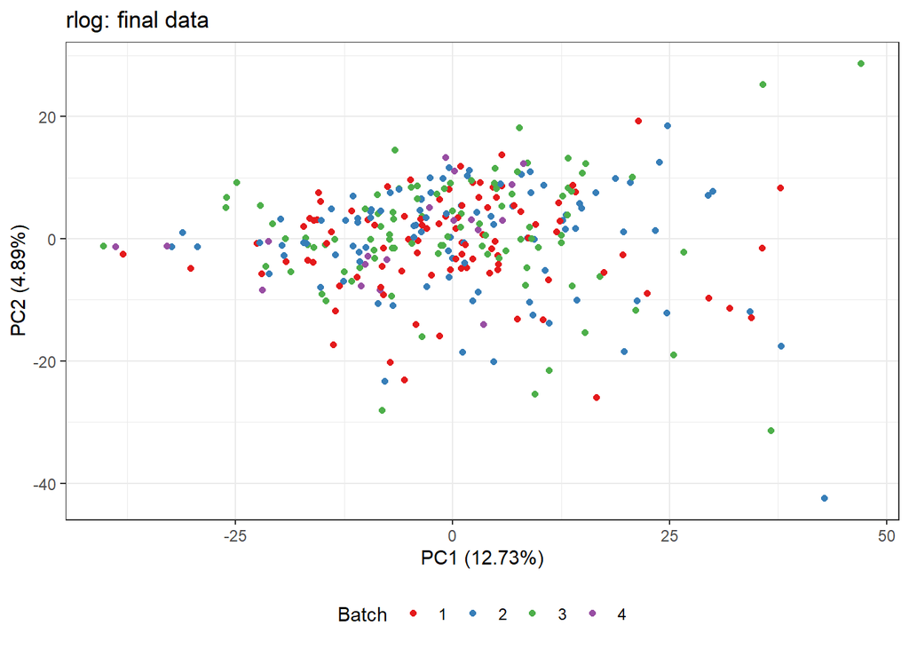

Let’s look at the technical replicates in the PC plot:

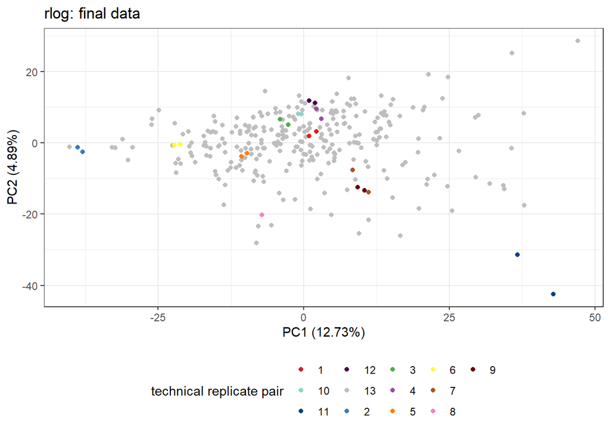

In the end we have **306** RNA seq runs (columns) in the final matrix, which corresponds to **295** unique samples.

Final dataset will be saved under:

```r
/home/biostats_share/Norris/data/RNAseq/finalDatasets/geneLevel/RSEM.RUVs.k1.rlog.Dec2020.Rdata
```